# hw_10

Merly Klaas

11/30/2021

# 2a. Reorder factors

- Get familiar with the gss_cat data within the {forcats} package.
- Remove the rows with missing data in the tvhours column
- Calculate the mean tvhours by marital status.
- Display the results as a point plot of average TV consumption by marital status (tvhours on the x-axis and martial on they y-axis)
- In your plot, reorder the levels of marital according to tvhours.
- Give your plot meaningful axis labels and a title.

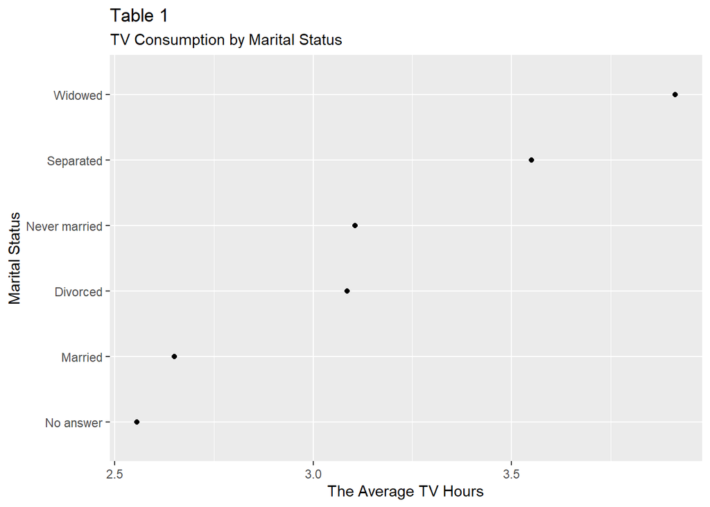

```r
summary <- gss_cat %>%
  filter(!is.na(tvhours)) %>%
  group_by(marital) %>%
  summarise(tvhours_mean = mean(tvhours, na.rm = TRUE)) %>%
  mutate(marital = fct_reorder(marital, tvhours_mean))

summary %>% ggplot(aes(tvhours_mean, marital)) +
  geom_point() +
    labs(title = "Table 1",
         subtitle = "TV Consumption by Marital Status",
         x = "The Average TV Hours",
         y = "Marital Status")
```

# 2b. Working with tables

- Display the same results (mean tvhours by marital status) as a table using kable().
- Change the column names.
- Round the mean tvhours to one decimal.
- Bold the row with the highest mean tvhours.

```r
gss_cat %>%
  filter(!is.na(tvhours)) %>%
  group_by(marital) %>%
  summarise(tvhours_mean = mean(tvhours, na.rm = TRUE)) %>%
  mutate(marital = fct_reorder(marital, tvhours_mean)) %>%
  arrange(tvhours_mean) %>%
  kable(
    col.names = c("Marital Status", "Average TV Hours"),
    digits = 1) %>%
    row_spec(6, bold = TRUE)
```

| Marital Status | Average TV Hours |
| --- | --- |
| No answer | 2.6 |
| Married | 2.7 |
| Divorced | 3.1 |
| Never married | 3.1 |
| Separated | 3.5 |
| Widowed | 3.9 |

# 3a. Recode factors

- Use any of the functions we talked about in class to display the levels of the marital variable.
- Recode or collapse the marital column into three categories: “Not married”, “Married”, and “No answer”.
- Calculate the mean tvhours by marital status.
- Display the results as a column plot of average TV consumption by marital status (martial on the x-axis and tvhours on they y-axis).
- From left to right, the columns in your plot should read: “Not married”, “Married”, and “No answer”.
- Make your plot look a little nicer with some color, different theme, meaningful axis labels, and a title.

```r
levels(gss_cat$marital)
```

```
## [1] "No answer"     "Never married" "Separated"     "Divorced"
## [5] "Widowed"       "Married"
```

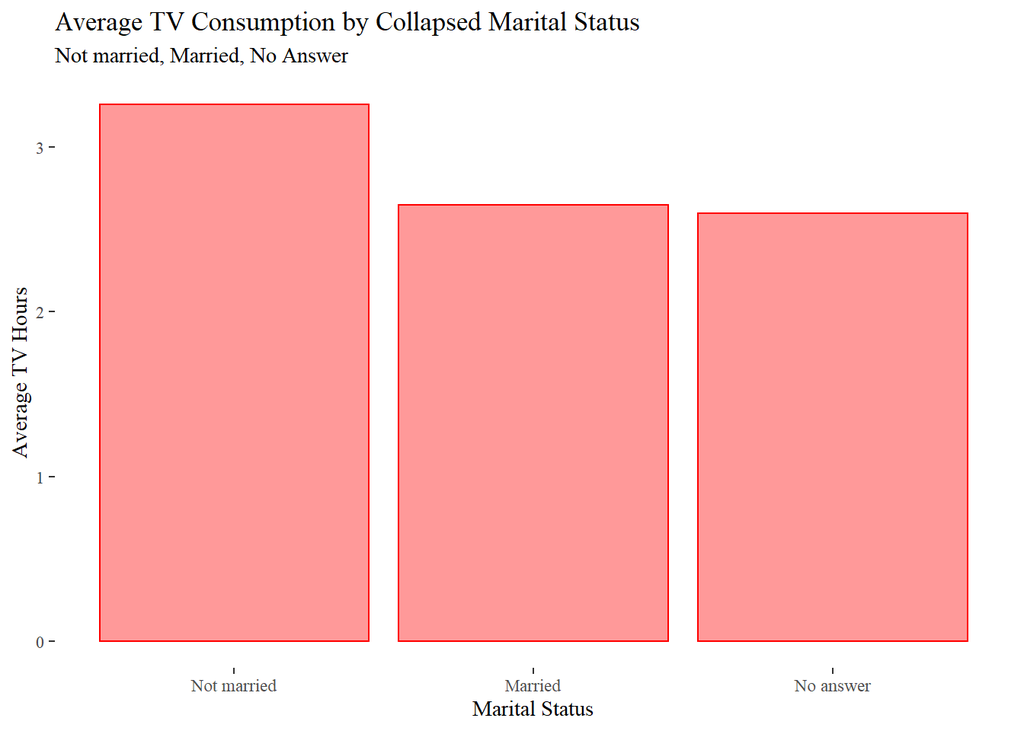

```r
gss_cat %>%
  drop_na() %>%
  mutate(marital = fct_collapse(marital,
                                `Not married` = c("Never married", "Separated", "Divorced", "Widowed"),
                                Married = c("Married"),
                                `No Answer` = c("No Answer"))) %>%
  group_by(marital) %>%
  summarize(tv_hours_mean = mean(tvhours)) %>%
  mutate(marital = fct_relevel(marital,
              "Not married",
              "Married",
              "No Answer")) %>%
  ggplot(aes(marital,tv_hours_mean)) +
  geom_col(stat ="identity", fill = "#FF9999", color = "red")+
  theme_tufte() +
  scale_fill_manual(values = colorblind_pal()(3)) +
  scale_color_manual(values = colorblind_pal()(3))+
  labs(title = "Average TV Consumption by Collapsed Marital Status",
       subtitle = "Not married, Married, No Answer",
       x = "Marital Status",
       y = "Average TV Hours")
```

# 3b. Working with tables

- Display the same results (mean tvhours by collapsed marital status) as a table using the {gt}.
- Change the column names.
- Round the mean tvhours to one decimal.
- Highlight in yellow the row with the lowest mean tvhours.

```r
gss_cat %>%
  drop_na() %>%
  mutate(marital = fct_collapse(marital,
                                `Not married` = c("Never married", "Separated", "Divorced", "Widowed"),
                                Married = c("Married"),
                                `No Answer` = c("No Answer"))) %>%
  group_by(marital) %>%
  summarize(tv_hours_mean = mean(tvhours)) %>%
  arrange(desc(tv_hours_mean)) %>%
  gt() %>%
  cols_label(marital = "collapsed_marital_status",
             tv_hours_mean = "average_tvhours") %>%
  fmt_number(columns = 2,
             decimals = 1) %>%
  tab_style(
    cell_fill(color = "yellow"),
    locations = (cells_body(
      rows = 3))
    )
```

| collapsed_marital_status | average_tvhours |
| --- | --- |
| Not married | 3.3 |
| Married | 2.7 |
| No answer | 2.6 |